```python
import numpy as np
import pandas as pd
import matplotlib.pyplot as plt
import seaborn as sns
import gc,os,sys
import re

from sklearn import metrics, preprocessing
from sklearn.model_selection import StratifiedKFold
from sklearn.decomposition import PCA, KernelPCA
from sklearn.cluster import KMeans
from tqdm import tqdm

import warnings
warnings.filterwarnings('ignore')

sns.set_style('darkgrid')

pd.options.display.float_format = '{:,.3f}'.format

print(os.listdir("data"))
```

```
['test_transaction.csv', 'train_identity.csv', 'test_identity.csv', 'sample_submission.csv', 'train_transaction.csv']
```

```python
# Memory saving function credit to https://www.kaggle.com/gemartin/load-data-reduce-memory-usage
def reduce_mem_usage(df):
    """ iterate through all the columns of a dataframe and modify the data type
        to reduce memory usage.
    """
    start_mem = df.memory_usage().sum() / 1024**2

    for col in df.columns:
        col_type = df[col].dtype

        if col_type != object:
            c_min = df[col].min()
            c_max = df[col].max()
            if str(col_type)[:3] == 'int':
                if c_min > np.iinfo(np.int8).min and c_max < np.iinfo(np.int8).max:
                    df[col] = df[col].astype(np.int8)
                elif c_min > np.iinfo(np.int16).min and c_max < np.iinfo(np.int16).max:
                    df[col] = df[col].astype(np.int16)
                elif c_min > np.iinfo(np.int32).min and c_max < np.iinfo(np.int32).max:
                    df[col] = df[col].astype(np.int32)
                elif c_min > np.iinfo(np.int64).min and c_max < np.iinfo(np.int64).max:
                    df[col] = df[col].astype(np.int64)
            else:
                if c_min > np.finfo(np.float16).min and c_max < np.finfo(np.float16).max:
                    df[col] = df[col].astype(np.float16)
                elif c_min > np.finfo(np.float32).min and c_max < np.finfo(np.float32).max:
                    df[col] = df[col].astype(np.float32)
                else:
                    df[col] = df[col].astype(np.float64)
        #else:
            #df[col] = df[col].astype('category')

    end_mem = df.memory_usage().sum() / 1024**2
    print('Memory usage of dataframe is {:.2f} MB --> {:.2f} MB (Decreased by {:.1f}%)'.format(
        start_mem, end_mem, 100 * (start_mem - end_mem) / start_mem))
    return df
```

# Load data

```python
%%time
train_id = pd.read_csv('data/train_identity.csv')
train_trn = pd.read_csv('data/train_transaction.csv')
test_id = pd.read_csv('data/test_identity.csv')
test_trn = pd.read_csv('data/test_transaction.csv')
```

```
CPU times: user 35.2 s, sys: 5.5 s, total: 40.7 s
Wall time: 35.4 s
```

```python
train_id = reduce_mem_usage(train_id)
train_trn = reduce_mem_usage(train_trn)
test_id = reduce_mem_usage(test_id)
test_trn = reduce_mem_usage(test_trn)
```

```
Memory usage of dataframe is 45.12 MB --> 25.86 MB (Decreased by 42.7%)
Memory usage of dataframe is 1775.15 MB --> 542.35 MB (Decreased by 69.4%)
Memory usage of dataframe is 44.39 MB --> 25.44 MB (Decreased by 42.7%)
Memory usage of dataframe is 1519.24 MB --> 472.59 MB (Decreased by 68.9%)
```

```python
print(train_id.shape, test_id.shape)
print(train_trn.shape, test_trn.shape)
```

```
(144233, 41) (141907, 41)
(590540, 394) (506691, 393)
```

# Data analysis

### what's target?

```python
[c for c in train_trn.columns if c not in test_trn.columns]
```

```
['isFraud']
```

### isFraud

|  | 0 | 1 |
| --- | --- | --- |
| isFraud | 0.965 | 0.035 |

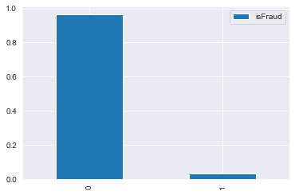

```python
fc = train_trn['isFraud'].value_counts(normalize=True).to_frame()
fc.plot.bar()
fc.T
```

- fraud transaction rate by day, and week

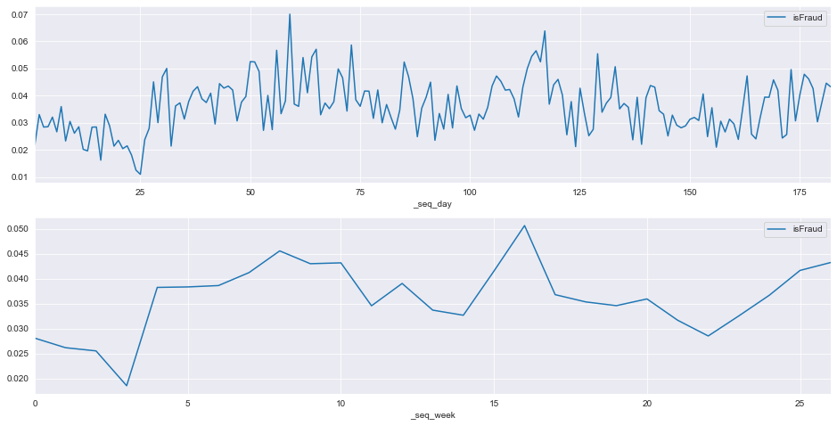

```python
fig,ax = plt.subplots(2, 1, figsize=(16,8))

train_trn['_seq_day'] = train_trn['TransactionDT'] // (24*60*60)
train_trn['_seq_week'] = train_trn['_seq_day'] // 7
train_trn.groupby('_seq_day')['isFraud'].mean().to_frame().plot.line(ax=ax[0])
train_trn.groupby('_seq_week')['isFraud'].mean().to_frame().plot.line(ax=ax[1])
```

- fraud transaction rate by weekday, hour, month-day, and year-month

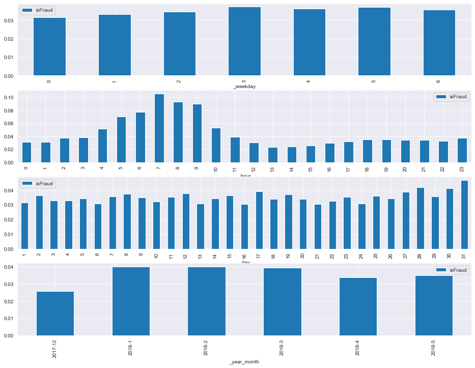

```python
import datetime

START_DATE = '2017-11-30'
startdate = datetime.datetime.strptime(START_DATE, "%Y-%m-%d")
train_trn['Date'] = train_trn['TransactionDT'].apply(lambda x: (startdate + datetime.timedelta(seconds=x)))
train_trn['_ymd'] = train_trn['Date'].dt.year.astype(str) + '-' + train_trn['Date'].dt.month.astype(str) + '-' + train_trn['Date'].dt.day.astype(str)
train_trn['_year_month'] = train_trn['Date'].dt.year.astype(str) + '-' + train_trn['Date'].dt.month.astype(str)
train_trn['_weekday'] = train_trn['Date'].dt.dayofweek
train_trn['_hour'] = train_trn['Date'].dt.hour
train_trn['_day'] = train_trn['Date'].dt.day

fig,ax = plt.subplots(4, 1, figsize=(16,12))

train_trn.groupby('_weekday')['isFraud'].mean().to_frame().plot.bar(ax=ax[0])
train_trn.groupby('_hour')['isFraud'].mean().to_frame().plot.bar(ax=ax[1])
train_trn.groupby('_day')['isFraud'].mean().to_frame().plot.bar(ax=ax[2])
train_trn.groupby('_year_month')['isFraud'].mean().to_frame().plot.bar(ax=ax[3])
```

- fraud transaction rate by day

```python
df = train_trn.groupby(['_ymd'])['isFraud'].agg(['count','mean','sum'])
df.sort_values(by='mean',ascending=False)[:10].T
```

| _ymd | 2018-1-28 | 2018-3-27 | 2018-2-11 | 2018-2-3 | 2018-1-25 | 2018-3-25 | 2018-4-8 | 2018-3-24 | 2018-2-2 | 2018-1-31 |
| --- | --- | --- | --- | --- | --- | --- | --- | --- | --- | --- |
| count | 2,402.000 | 3,042.000 | 2,304.000 | 3,209.000 | 2,789.000 | 2,461.000 | 2,348.000 | 2,758.000 | 4,317.000 | 3,057.000 |
| mean | 0.070 | 0.064 | 0.059 | 0.057 | 0.057 | 0.056 | 0.055 | 0.054 | 0.054 | 0.054 |
| sum | 168.000 | 194.000 | 135.000 | 183.000 | 158.000 | 139.000 | 130.000 | 150.000 | 234.000 | 165.000 |

```python
df.sort_values(by='count',ascending=False)[:10].T
```

| _ymd | 2017-12-22 | 2018-3-2 | 2017-12-24 | 2017-12-23 | 2017-12-20 | 2017-12-25 | 2017-12-21 | 2017-12-18 | 2017-12-19 | 2017-12-1 |
| --- | --- | --- | --- | --- | --- | --- | --- | --- | --- | --- |
| count | 6,852.000 | 6,252.000 | 6,065.000 | 5,872.000 | 5,749.000 | 5,742.000 | 5,677.000 | 5,585.000 | 5,526.000 | 5,122.000 |
| mean | 0.021 | 0.024 | 0.013 | 0.018 | 0.023 | 0.011 | 0.020 | 0.029 | 0.021 | 0.022 |
| sum | 147.000 | 147.000 | 76.000 | 106.000 | 135.000 | 63.000 | 116.000 | 161.000 | 118.000 | 112.000 |

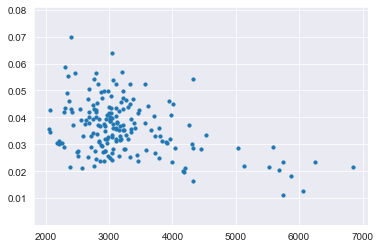

```python
# transaction-count X fraud-rate
plt.scatter(df['count'], df['mean'], s=10)
```

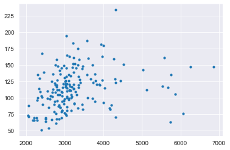

```python
# transaction-count X fraud-count
plt.scatter(df['count'], df['sum'], s=10)
```

- fraud transaction rate by weekday-hour

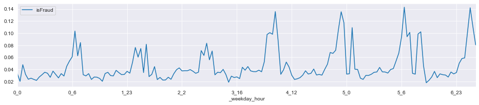

```python
train_trn['_weekday_hour'] = train_trn['_weekday'].astype(str) + '_' + train_trn['_hour'].astype(str)
train_trn.groupby('_weekday_hour')['isFraud'].mean().to_frame().plot.line(figsize=(16,3))
```

- fraud rate by weekday

```python
df = train_trn.groupby('_weekday')['isFraud'].mean().to_frame()
df.sort_values(by='isFraud', ascending=False)
```

| _weekday | isFraud |
| --- | --- |
| 3 | 0.037 |
| 5 | 0.037 |
| 4 | 0.036 |
| 6 | 0.036 |
| 2 | 0.035 |
| 1 | 0.033 |
| 0 | 0.031 |

- fraud rate by hour

```python
df = train_trn.groupby('_hour')['isFraud'].mean().to_frame()
df.sort_values(by='isFraud', ascending=False).head(10)
```

| _hour | isFraud |
| --- | --- |
| 7 | 0.106 |
| 8 | 0.093 |
| 9 | 0.090 |
| 6 | 0.078 |
| 5 | 0.070 |
| 10 | 0.053 |
| 4 | 0.052 |
| 11 | 0.039 |
| 3 | 0.038 |
| 2 | 0.037 |

- fraud rate by weekday-hour

```python
df = train_trn.groupby('_weekday_hour')['isFraud'].mean().to_frame()
df.sort_values(by='isFraud', ascending=False).head(10)
```

| _weekday_hour | isFraud |
| --- | --- |
| 5_7 | 0.143 |
| 6_7 | 0.142 |
| 3_8 | 0.136 |
| 4_8 | 0.135 |
| 4_9 | 0.117 |
| 6_8 | 0.110 |
| 5_10 | 0.109 |
| 4_7 | 0.106 |
| 0_7 | 0.103 |
| 6_11 | 0.102 |

- fraud rate by amount-bin

```python
train_trn['_amount_qcut10'] = pd.qcut(train_trn['TransactionAmt'],10)
df = train_trn.groupby('_amount_qcut10')['isFraud'].mean().to_frame()
df.sort_values(by='isFraud', ascending=False)
```

| _amount_qcut10 | isFraud |
| --- | --- |
| (0.25, 25.953] | 0.056 |
| (275.25, 31936.0] | 0.051 |
| (117.0, 160.0] | 0.043 |
| (160.0, 275.25] | 0.038 |
| (68.75, 100.0] | 0.036 |
| (35.938, 49.0] | 0.032 |
| (25.953, 35.938] | 0.032 |
| (57.938, 68.75] | 0.029 |
| (100.0, 117.0] | 0.020 |
| (49.0, 57.938] | 0.019 |

### TransactionID

```python
# Not all transactions have corresponding identity information.
#len([c for c in train_trn['TransactionID'] if c not in train_id['TransactionID'].values]) #446307

# Not all fraud transactions have corresponding identity information.
fraud_id = train_trn[train_trn['isFraud'] == 1]['TransactionID']
fraud_id_in_trn = [i for i in fraud_id if i in train_id['TransactionID'].values]
print(f'fraud data count:{len(fraud_id)}, and in trn:{len(fraud_id_in_trn)}')
```

```
fraud data count:20663, and in trn:11318
```

## Identity data

Variables in this table are identity information – network connection information (IP, ISP, Proxy, etc) and digital signature (UA/browser/os/version, etc) associated with transactions. They're collected by Vesta’s fraud protection system and digital security partners. (The field names are masked and pairwise dictionary will not be provided for privacy protection and contract agreement)

Categorical Features:

- DeviceType
- DeviceInfo
- id12 - id38

```python
train_id_trn = pd.merge(train_id, train_trn[['isFraud','TransactionAmt','TransactionID']])
train_id_f0 = train_id_trn[train_id_trn['isFraud'] == 0]
train_id_f1 = train_id_trn[train_id_trn['isFraud'] == 1]
print(train_id_f0.shape, train_id_f1.shape)

def plotHistByFraud(col, bins=20, figsize=(8,3)):
    with np.errstate(invalid='ignore'):
        plt.figure(figsize=figsize)
        plt.hist([train_id_f0[col], train_id_f1[col]], bins=bins, density=True, color=['royalblue', 'orange'])

def plotCategoryRateBar(col, topN=np.nan, figsize=(8,3)):
    a, b = train_id_f0, train_id_f1
    if topN == topN: # isNotNan
        vals = b[col].value_counts(normalize=True).to_frame().iloc[:topN,0]
        subA = a.loc[a[col].isin(vals.index.values), col]
        df = pd.DataFrame({'normal':subA.value_counts(normalize=True), 'fraud':vals})
    else:
        df = pd.DataFrame({'normal':a[col].value_counts(normalize=True), 'fraud':b[col].value_counts(normalize=True)})
    df.sort_values('fraud', ascending=False).plot.bar(figsize=figsize)
```

```
(132915, 43) (11318, 43)
```

### id_01 - id_11

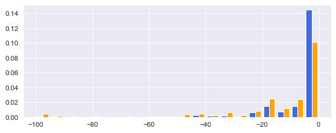

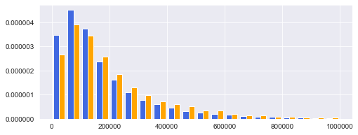

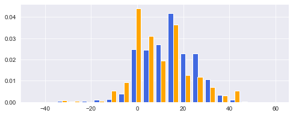

```python
plotHistByFraud('id_01')
plotHistByFraud('id_02')
plotHistByFraud('id_07')
```

```python
numid_cols = [f'id_{str(i).zfill(2)}' for i in range(1,12)]
train_id_trn[numid_cols].isna().sum().to_frame().T / len(train_id)
```

|  | id_01 | id_02 | id_03 | id_04 | id_05 | id_06 | id_07 | id_08 | id_09 | id_10 | id_11 |
| --- | --- | --- | --- | --- | --- | --- | --- | --- | --- | --- | --- |
| 0 | 0.000 | 0.023 | 0.540 | 0.540 | 0.051 | 0.051 | 0.964 | 0.964 | 0.481 | 0.481 | 0.023 |

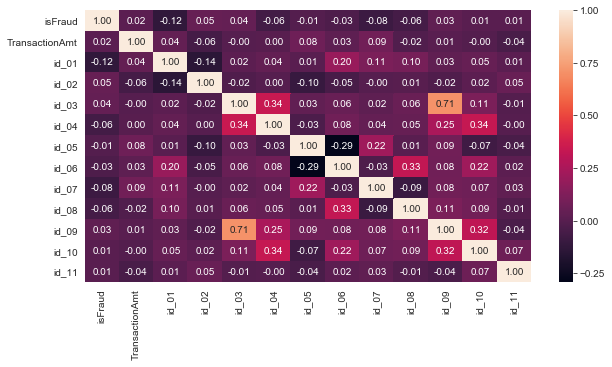

```python
plt.figure(figsize=(10, 5))
sns.heatmap(train_id_trn[['isFraud','TransactionAmt']+numid_cols].corr(), annot=True, fmt='.2f')
```

```python
train_id_f1[['isFraud'] + numid_cols].head(10)
```

|  | isFraud | id_01 | id_02 | id_03 | id_04 | id_05 | id_06 | id_07 | id_08 | id_09 | id_10 | id_11 |
| --- | --- | --- | --- | --- | --- | --- | --- | --- | --- | --- | --- | --- |
| 52 | 1 | 0.000 | 169,947.000 | 0.000 | 0.000 | 3.000 | 0.000 | nan | nan | 0.000 | 0.000 | 100.000 |
| 53 | 1 | 0.000 | 222,455.000 | 0.000 | 0.000 | 0.000 | 0.000 | nan | nan | 0.000 | 0.000 | 100.000 |
| 54 | 1 | 0.000 | 271,870.000 | 0.000 | 0.000 | 3.000 | 0.000 | nan | nan | 0.000 | 0.000 | 100.000 |
| 69 | 1 | -20.000 | 258,138.000 | nan | nan | 0.000 | -1.000 | nan | nan | nan | nan | 100.000 |
| 86 | 1 | -5.000 | 141,271.000 | nan | nan | 9.000 | -81.000 | nan | nan | 0.000 | 0.000 | 97.562 |
| 98 | 1 | -20.000 | 550,210.000 | nan | nan | 0.000 | -1.000 | nan | nan | nan | nan | 100.000 |
| 185 | 1 | -25.000 | 59,967.000 | nan | nan | 1.000 | -12.000 | nan | nan | nan | nan | 100.000 |
| 201 | 1 | -5.000 | 30,602.000 | nan | nan | 0.000 | -12.000 | nan | nan | 0.000 | 0.000 | 95.062 |
| 235 | 1 | -5.000 | 4,235.000 | nan | nan | 0.000 | 0.000 | nan | nan | nan | nan | 100.000 |
| 236 | 1 | 0.000 | 36,004.000 | 0.000 | 0.000 | 0.000 | 0.000 | nan | nan | 0.000 | 0.000 | 100.000 |

```python
train_id_f0[['isFraud'] + numid_cols].head(10)
```

|  | isFraud | id_01 | id_02 | id_03 | id_04 | id_05 | id_06 | id_07 | id_08 | id_09 | id_10 | id_11 |
| --- | --- | --- | --- | --- | --- | --- | --- | --- | --- | --- | --- | --- |
| 0 | 0 | 0.000 | 70,787.000 | nan | nan | nan | nan | nan | nan | nan | nan | 100.000 |
| 1 | 0 | -5.000 | 98,945.000 | nan | nan | 0.000 | -5.000 | nan | nan | nan | nan | 100.000 |
| 2 | 0 | -5.000 | 191,631.000 | 0.000 | 0.000 | 0.000 | 0.000 | nan | nan | 0.000 | 0.000 | 100.000 |
| 3 | 0 | -5.000 | 221,832.000 | nan | nan | 0.000 | -6.000 | nan | nan | nan | nan | 100.000 |
| 4 | 0 | 0.000 | 7,460.000 | 0.000 | 0.000 | 1.000 | 0.000 | nan | nan | 0.000 | 0.000 | 100.000 |
| 5 | 0 | -5.000 | 61,141.000 | 3.000 | 0.000 | 3.000 | 0.000 | nan | nan | 3.000 | 0.000 | 100.000 |
| 6 | 0 | -15.000 | nan | nan | nan | nan | nan | nan | nan | nan | nan | nan |
| 7 | 0 | 0.000 | 31,964.000 | 0.000 | 0.000 | 0.000 | -10.000 | nan | nan | 0.000 | 0.000 | 100.000 |
| 8 | 0 | -10.000 | 116,098.000 | 0.000 | 0.000 | 0.000 | 0.000 | nan | nan | 0.000 | 0.000 | 100.000 |
| 9 | 0 | -5.000 | 257,037.000 | nan | nan | 0.000 | 0.000 | nan | nan | nan | nan | 100.000 |

### id_12 - id_38

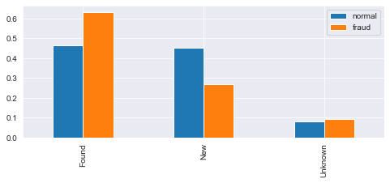

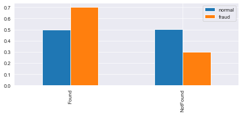

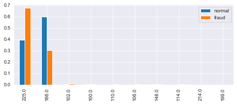

```python
plotCategoryRateBar('id_15')
plotCategoryRateBar('id_16')
plotCategoryRateBar('id_17',10)
```

```
unique count: 522
```

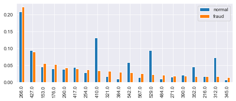

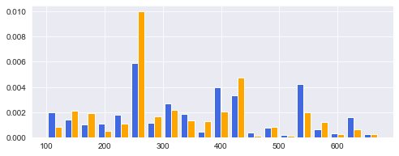

```python
plotCategoryRateBar('id_19', 20)
plotHistByFraud('id_19')
print('unique count:', train_id['id_19'].nunique())
```

```
unique count: 394
```

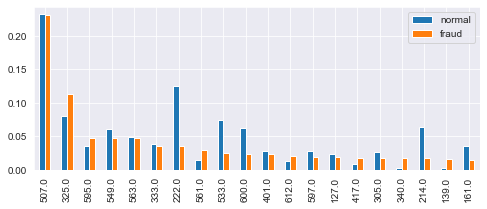

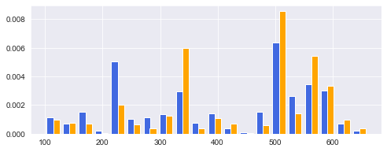

```python
plotCategoryRateBar('id_20', 20)
plotHistByFraud('id_20')
print('unique count:', train_id['id_20'].nunique())
```

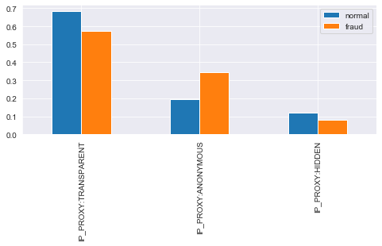

```python
plotCategoryRateBar('id_23')
```

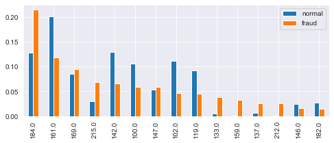

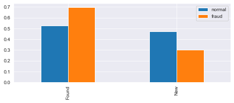

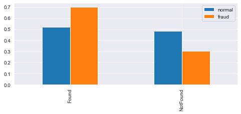

```python
plotCategoryRateBar('id_26', 15)
plotCategoryRateBar('id_28')
plotCategoryRateBar('id_29')
```

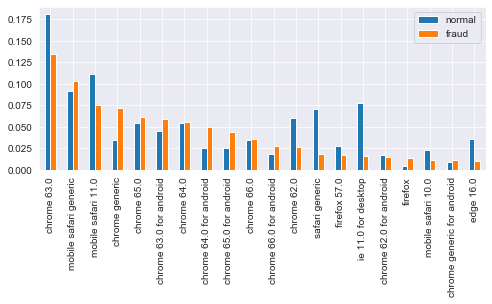

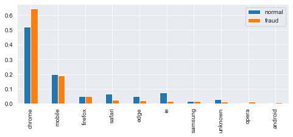

```python
plotCategoryRateBar('id_31', 20)

train_id_f0['_id_31_ua'] = train_id_f0['id_31'].apply(lambda x: x.split()[0] if x == x else 'unknown')
train_id_f1['_id_31_ua'] = train_id_f1['id_31'].apply(lambda x: x.split()[0] if x == x else 'unknown')
plotCategoryRateBar('_id_31_ua', 10)
```

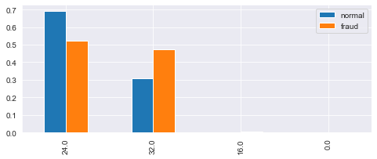

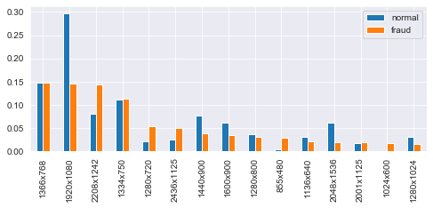

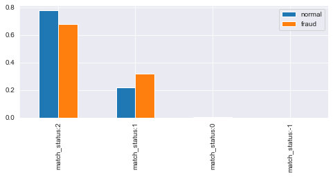

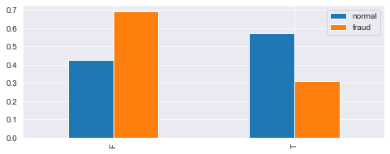

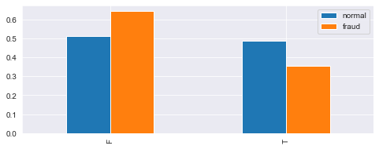

```python
plotCategoryRateBar('id_32')
plotCategoryRateBar('id_33',15)
plotCategoryRateBar('id_34')
plotCategoryRateBar('id_35')
plotCategoryRateBar('id_38')
```

### DeviceType, DeviceInfo

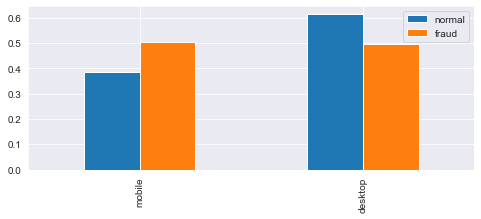

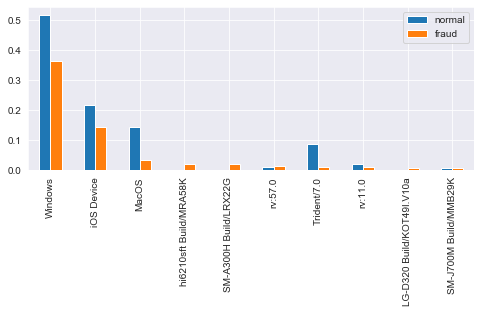

```python
plotCategoryRateBar('DeviceType')
plotCategoryRateBar('DeviceInfo',10)
```

## Transaction data

- TransactionDT: timedelta from a given reference datetime (not an actual timestamp)
- TransactionAMT: transaction payment amount in USD
- ProductCD: product code, the product for each transaction
- card1 - card6: payment card information, such as card type, card category, issue bank, country, etc.
- addr: address
- dist: distance
- P_ and (R__) emaildomain: purchaser and recipient email domain
- C1-C14: counting, such as how many addresses are found to be associated with the payment card, etc. The actual meaning is masked.
- D1-D15: timedelta, such as days between previous transaction, etc.
- M1-M9: match, such as names on card and address, etc.
- Vxxx: Vesta engineered rich features, including ranking, counting, and other entity relations.

```python
ccols = [f'C{i}' for i in range(1,15)]
dcols = [f'D{i}' for i in range(1,16)]
mcols = [f'M{i}' for i in range(1,10)]
vcols = [f'V{i}' for i in range(1,340)]
```

```python
train_trn_f0 = train_trn[train_trn['isFraud'] == 0]
train_trn_f1 = train_trn[train_trn['isFraud'] == 1]
print(train_trn_f0.shape, train_trn_f1.shape)

def plotTrnHistByFraud(col, bins=20, figsize=(8,3)):
    with np.errstate(invalid='ignore'):
        plt.figure(figsize=figsize)
        plt.hist([train_trn_f0[col], train_trn_f1[col]], bins=bins, density=True, color=['royalblue', 'orange'])

def plotTrnLogHistByFraud(col, bins=20, figsize=(8,3)):
    with np.errstate(invalid='ignore'):
        plt.figure(figsize=figsize)
        plt.hist([np.log1p(train_trn_f0[col]), np.log1p(train_trn_f1[col])], bins=bins, density=True, color=['royalblue', 'orange'])

def plotTrnCategoryRateBar(col, topN=np.nan, figsize=(8,3)):
    a, b = train_trn_f0, train_trn_f1
    if topN == topN: # isNotNan
        vals = b[col].value_counts(normalize=True).to_frame().iloc[:topN,0]
        subA = a.loc[a[col].isin(vals.index.values), col]
        df = pd.DataFrame({'normal':subA.value_counts(normalize=True), 'fraud':vals})
    else:
        df = pd.DataFrame({'normal':a[col].value_counts(normalize=True), 'fraud':b[col].value_counts(normalize=True)})
    df.sort_values('fraud', ascending=False).plot.bar(figsize=figsize)
```

```
(569877, 404) (20663, 404)
```